# Mobile App vs Website- A Linear Regression Approach to Customer Spending

## Import the necessary Libraries

```python
import pandas as pd
import numpy as np
import matplotlib.pyplot as plt
import seaborn as sns
%matplotlib inline
```

### import the data

```python
customers = pd.read_excel("C:/Users/admin/Desktop/E_commerce_linear_regression/Ecommerce Customers.xlsx")
```

```python
customers.head()
```

|  | Email | Address | Avatar | Avg. Session Length | Time on App | Time on Website | Length of Membership | Yearly Amount Spent |
| --- | --- | --- | --- | --- | --- | --- | --- | --- |
| 0 | mstephenson@fernandez.com | 835 Frank Tunnel | NaN | NaN | NaN | NaN | NaN | NaN |
| 1 | Wrightmouth | " MI 82180-9605""" | Violet | 34.497268 | 12.655651 | 39.577668 | 4.082621 | 587.951054 |
| 2 | hduke@hotmail.com | 4547 Archer Common | NaN | NaN | NaN | NaN | NaN | NaN |
| 3 | Diazchester | " CA 06566-8576""" | DarkGreen | 31.926272 | 11.109461 | 37.268959 | 2.664034 | 392.204933 |
| 4 | pallen@yahoo.com | 24645 Valerie Unions Suite 582 | NaN | NaN | NaN | NaN | NaN | NaN |

```python
# Summary statistics
print(customers.describe())
```

```
       Avg. Session Length  Time on App  Time on Website  \
count           500.000000   500.000000       500.000000
mean             31.130462    14.350284        33.956926
std               6.128380     7.327838         9.787361
min               8.668350     8.508152         0.789520
25%              32.086022    11.469670        36.088966
50%              32.904773    12.109744        36.943004
75%              33.636921    12.992473        37.648456
max              36.139662    39.220713        40.005182

       Length of Membership  Yearly Amount Spent
count            500.000000           454.000000
mean              48.607305           499.919858
std              144.216919            78.325793
min                0.269901           266.086341
25%                3.014640           445.917049
50%                3.653135           498.887875
75%                4.534414           549.100737
max              744.221867           765.518462
```

```python
# Info about data types and nulls
print(customers.info())
```

```
<class 'pandas.core.frame.DataFrame'>
RangeIndex: 1000 entries, 0 to 999
Data columns (total 8 columns):
 #   Column                Non-Null Count  Dtype
---  ------                --------------  -----
 0   Email                 1000 non-null   object
 1   Address               1000 non-null   object
 2   Avatar                516 non-null    object
 3   Avg. Session Length   500 non-null    float64
 4   Time on App           500 non-null    float64
 5   Time on Website       500 non-null    float64
 6   Length of Membership  500 non-null    float64
 7   Yearly Amount Spent   454 non-null    float64
dtypes: float64(5), object(3)
memory usage: 62.6+ KB
None
```

#### Check for Missing Values

```python
# Check for nulls
print(customers.isnull().sum())
```

```
Email                     0
Address                   0
Avatar                  484
Avg. Session Length     500
Time on App             500
Time on Website         500
Length of Membership    500
Yearly Amount Spent     546
dtype: int64
```

```python
 # drop rows with missing values
 customers = customers.dropna()

# drop irrelevant columns
customers = customers.drop(['Email', 'Address', 'Avatar'], axis=1)

customers.head()
```

|  | Avg. Session Length | Time on App | Time on Website | Length of Membership | Yearly Amount Spent |
| --- | --- | --- | --- | --- | --- |
| 1 | 34.497268 | 12.655651 | 39.577668 | 4.082621 | 587.951054 |
| 3 | 31.926272 | 11.109461 | 37.268959 | 2.664034 | 392.204933 |
| 5 | 33.000915 | 11.330278 | 37.110597 | 4.104543 | 487.547505 |
| 7 | 34.305557 | 13.717514 | 36.721283 | 3.120179 | 581.852344 |
| 9 | 33.330673 | 12.795189 | 37.536653 | 4.446308 | 599.406092 |

### checking data type

```python
print(customers.dtypes)
```

```
Avg. Session Length     float64
Time on App             float64
Time on Website         float64
Length of Membership    float64
Yearly Amount Spent     float64
dtype: object
```

## Exploratory Data Analysis

```python
# Set plot style
sns.set(style="whitegrid")
sns.set_palette("GnBu_d")
```

### Correlation Heatmap

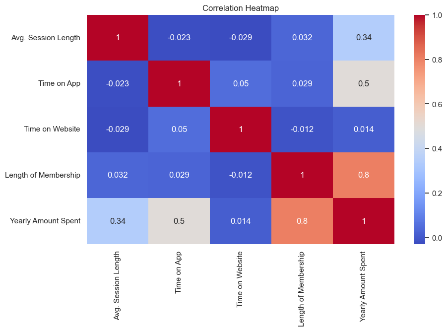

```python
plt.figure(figsize=(10, 6))
sns.heatmap(customers.corr(), annot=True, cmap="coolwarm")
plt.title("Correlation Heatmap")
plt.show()
```

### Pairplot for Feature Relationships

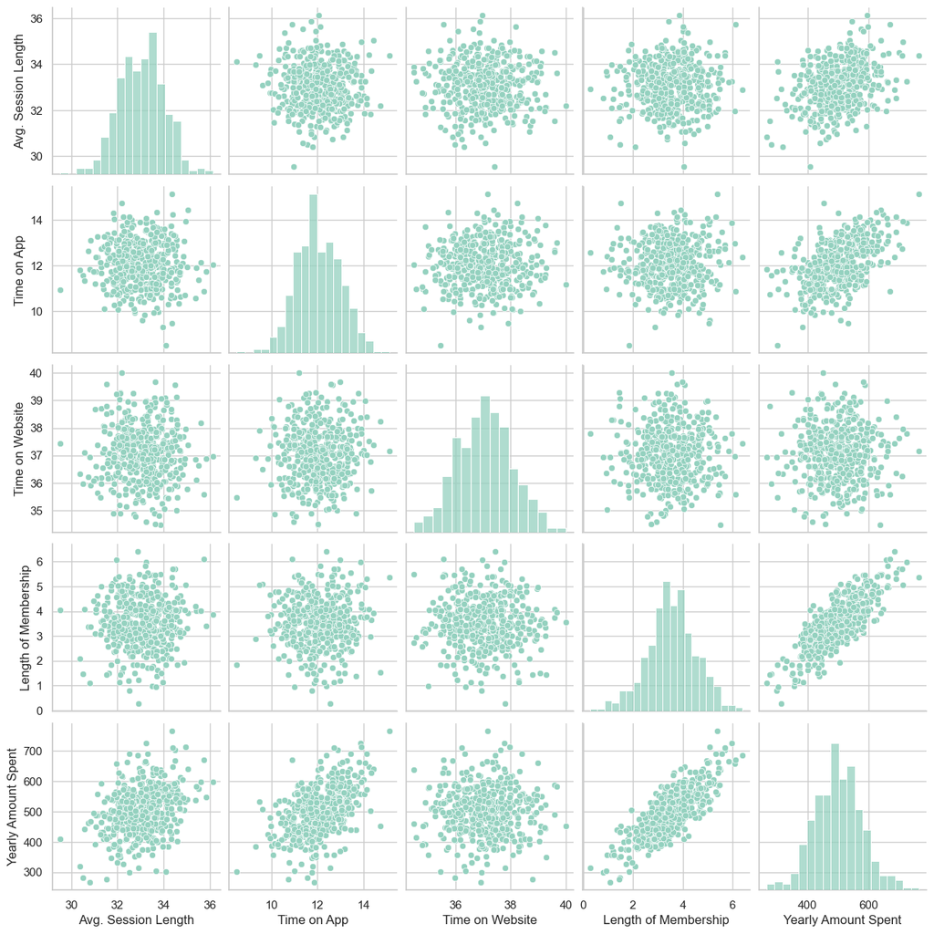

```python
sns.pairplot(customers)
plt.show()
```

### Distribution of Yearly Amount Spent

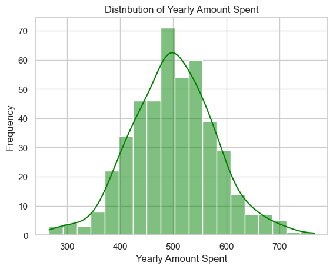

```python
sns.histplot(customers['Yearly Amount Spent'], kde=True, color='green')
plt.title("Distribution of Yearly Amount Spent")
plt.xlabel("Yearly Amount Spent")
plt.ylabel("Frequency")
plt.show()
```

### Relationships with Target Variable

#### Time on Website vs Yearly Amount Spent

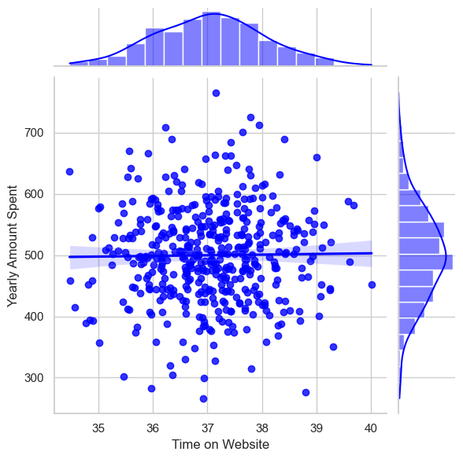

```python
sns.jointplot(x='Time on Website', y='Yearly Amount Spent', data=customers, kind='reg', color='blue')
plt.show()
```

#### Time on App vs Yearly Amount Spent

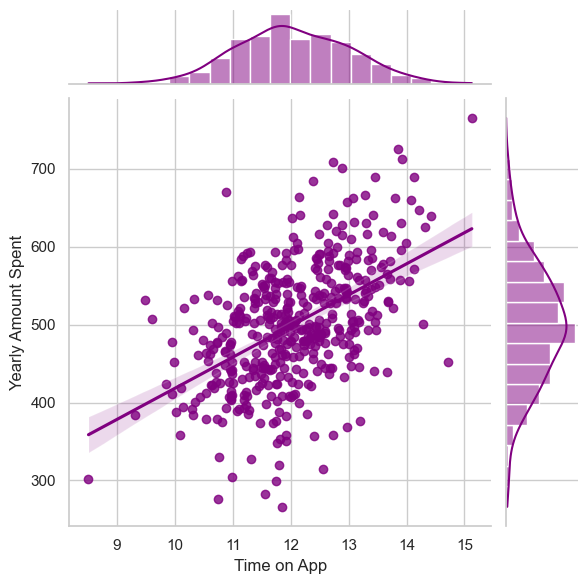

```python
sns.jointplot(x='Time on App', y='Yearly Amount Spent', data=customers, kind='reg', color='purple')
plt.show()
```

#### Length of Membership vs Yearly Amount Spent

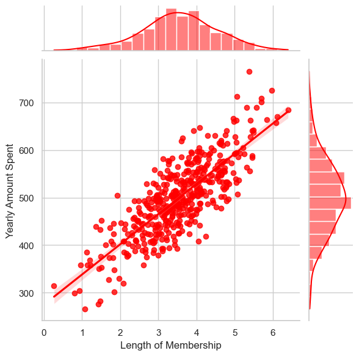

```python
sns.jointplot(x='Length of Membership', y='Yearly Amount Spent', data=customers, kind='reg', color='red')
plt.show()
```

#### Multivariate Analysis

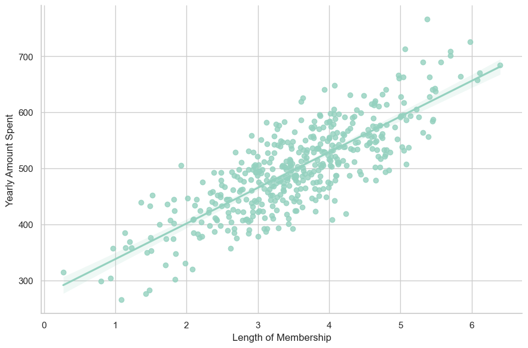

```python
sns.lmplot(x='Length of Membership', y='Yearly Amount Spent', data=customers,
           hue=None, palette='Set1', height=6, aspect=1.5)
plt.show()
```

#### Summary Statistics by Quartile

```python
customers['Membership_Quartile'] = pd.qcut(customers['Length of Membership'], 4)
group_stats = customers.groupby('Membership_Quartile')['Yearly Amount Spent'].describe()
print(group_stats)
```

```
                     count        mean        std         min         25%  \
Membership_Quartile
(0.269, 2.954]       114.0  420.607392  57.324718  266.086341  385.747933
(2.954, 3.534]       113.0  482.109328  46.726605  378.330907  448.340425
(3.534, 4.128]       113.0  519.933013  49.510440  408.640351  486.083425
(4.128, 6.401]       114.0  577.049020  60.405409  418.602742  535.684182

                            50%         75%         max
Membership_Quartile
(0.269, 2.954]       423.682743  457.900061  558.427257
(2.954, 3.534]       483.159721  508.771907  582.491924
(3.534, 4.128]       516.831557  554.003093  647.619456
(4.128, 6.401]       568.096293  613.295800  765.518462
```

## Training and Testing Data

```python
y = customers['Yearly Amount Spent']
X = customers[['Avg. Session Length', 'Time on App','Time on Website', 'Length of Membership']]
```

### split the dataset into train and test

```python
from sklearn.model_selection import train_test_split
```

```python
X_train, X_test, y_train, y_test = train_test_split(X, y, test_size=0.3, random_state=101)
```

## Training the Model

```python
# Import LinearRegression from sklearn.linear_model
from sklearn.linear_model import LinearRegression
```

```python
# Create an instance of a LinearRegression() model named lm
lm = LinearRegression()
```

```python
# Train/fit lm on the training data.
lm.fit(X_train,y_train)
```

```
LinearRegression()
```

```python
# The coefficients
print('Coefficients: \n', lm.coef_)
```

```
Coefficients:
 [25.8679068  39.5435202   0.62161736 61.48119726]
```

## Predicting Test Data

```python
predictions = lm.predict( X_test)
```

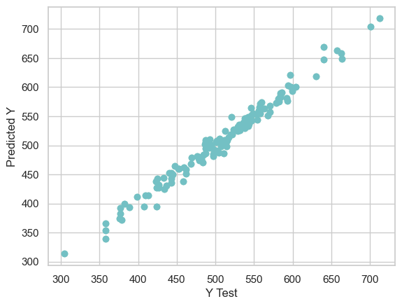

```python
# Create a scatterplot of the real test values versus the predicted values.
plt.scatter(y_test,predictions)
plt.xlabel('Y Test')
plt.ylabel('Predicted Y')
plt.show()
```

## Evaluating the Model

```python
# calculate the metrics
from sklearn import metrics

print('MAE:', metrics.mean_absolute_error(y_test, predictions))
print('MSE:', metrics.mean_squared_error(y_test, predictions))
print('RMSE:', np.sqrt(metrics.mean_squared_error(y_test, predictions)))
```

```
MAE: 8.042176495294282
MSE: 103.99375361008293
RMSE: 10.197732768124634
```

### Residuals

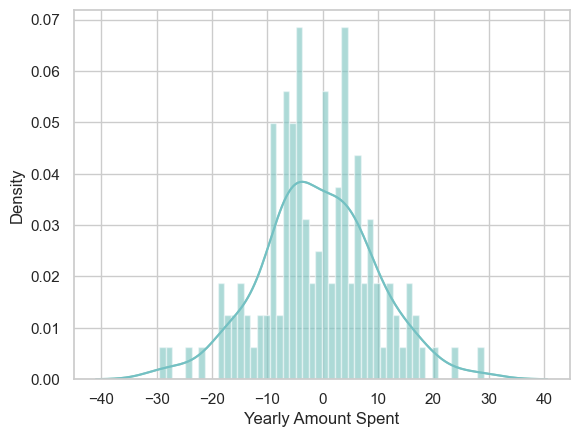

```python
sns.distplot((y_test-predictions),bins=50);
plt.show()
```

## Random Forest

```python
from sklearn.ensemble import RandomForestRegressor
from sklearn.metrics import mean_absolute_error, mean_squared_error
import numpy as np
```

```python
rf = RandomForestRegressor(n_estimators=100, random_state=42)
rf.fit(X_train, y_train)
```

```
RandomForestRegressor(random_state=42)
```

### Predictions and Evaluation

```python
rf_predictions = rf.predict(X_test)

# Evaluation Metrics
rf_mae = mean_absolute_error(y_test, rf_predictions)
rf_mse = mean_squared_error(y_test, rf_predictions)
rf_rmse = np.sqrt(rf_mse)

print(f"Random Forest MAE: {rf_mae}")
print(f"Random Forest MSE: {rf_mse}")
print(f"Random Forest RMSE: {rf_rmse}")
```

```
Random Forest MAE: 14.030867244335733
Random Forest MSE: 342.2750813069837
Random Forest RMSE: 18.500677860742933
```

### Feature Importance

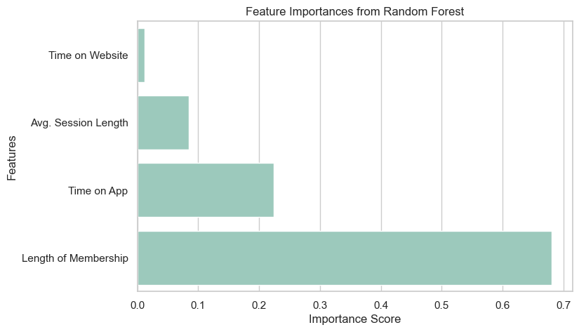

```python
feature_importances = pd.Series(rf.feature_importances_, index=X.columns)
plt.figure(figsize=(8, 5))
sns.barplot(x=feature_importances.sort_values(), y=feature_importances.sort_values().index)
plt.title("Feature Importances from Random Forest")
plt.xlabel("Importance Score")
plt.ylabel("Features")
plt.show()
```

## Conclusion

```python
coeffecients = pd.DataFrame(lm.coef_,X.columns)
coeffecients.columns = ['Coeffecient']
coeffecients
```

|  | Coeffecient |
| --- | --- |
| Avg. Session Length | 25.867907 |
| Time on App | 39.543520 |
| Time on Website | 0.621617 |
| Length of Membership | 61.481197 |

### How can you interpret these coefficients?

Interpreting the coefficients:

- Holding all other features fixed, a 1 unit increase in **Avg. Session Length** is associated with an **increase of 25.86 total dollars spent**.
- Holding all other features fixed, a 1 unit increase in **Time on App** is associated with an **increase of 39.54 total dollars spent**.
- Holding all other features fixed, a 1 unit increase in **Time on Website** is associated with an **increase of 0.62 total dollars spent**.
- Holding all other features fixed, a 1 unit increase in **Length of Membership** is associated with an **increase of 61.48 total dollars spent**.

### should the company focus more on their mobile app or on their website?

Time on App 39.54 dollars and over:  
Customers who spend more time on the mobile app tend to spend significantly more. For each extra unit of time (likely in minutes), there's a 39.54 dollars increase in annual spending — the second-highest effect after Length of Membership.

Time on Website +0.62 dollars: In contrast, more time on the website barely affects spending — a $0.62 increase per unit time is almost negligible.

Avg. Session Length +25.86 dollars and Length of Membership (+$61.48): These are also strong predictors, but not tied specifically to channel preference (app vs. website).

#### Recommendation to the Company

Focus on improving and investing in the mobile app.

Why?

It has a much stronger positive correlation with spending compared to the website.

Small increases in app engagement lead to big spending gains.

Website time has a very weak impact on purchases, so further optimizing it may not yield much return.